# Welcome & Syllabus

Lecture 01

# Course Details

## Course Team

### Instructor

- Chris Slaughter
  - james.c.slaughter@vumc.org (best)
  - james.c.slaughter@vanderbilt.edu (checked ~ weekly)
  - Office: 2525 West End, 11-127

### TA

- Chih-Ting Yang
- Haoyang Yi

## Course website(s)

- https://chrissl789.github.io/modern-regression/
  - Course notes
    - HTML, PDF, Quarto (.qmd)
  - Daily schedule
  - Links to course tools
- [Brightspace](https://brightspace.vanderbilt.edu)
  - Announcements
  - Submit homework and manage grades
  - FERPA compliance
    - The Family Educational Rights and Privacy Act (FERPA) is a federal law enacted in 1974 that protects the privacy of student education records.

## Course Timetable

- Lectures (weekly)
  - Tuesdays, 10:30 - 11:50 am - 2525 WEA, Room 11105
  - Thursdays, 10:30 - 11:50 am - 2525 WEA, Room 11105
- Labs (weekly)
  - Mondays, 1:00 to 1:50 pm - 2525 WEA, Room 11105

## Software – R

- Primary software package will be R
  - Free
  - Most adaptable statistical package
  - Used by the majority of academic Biostatisticians
  - [Rstudio](https://posit.co/downloads/) IDE used to work with R
  - Rstudio includes Quarto, the latest and greatest tool for rendering markdown documents

## Software – Stata

- Secondary software package will be Stata
  - My second favorite statistical package
  - Relatively easy syntax
  - Designed for people who know statistics, but don’t want to write basic functions
  - Not integrated with Quarto
    - I will provide a list of equivalent Stata commands in labs and lectures, but usually not produce the output

## Generative AI (e.g. ChatGPT, Claude)

- See syllabus for complete statement on the permitted uses of generative AI in this course
- If any questions, ask the instructor for clarifications
- As with any tool, use with caution
  - Help with generating code, or converting code between languages
  - Help with editing interpretations in more easily understood language
  - The prompt that you use matters. Also, identical prompts at different times can give different answers

## My views on generative AI

- Rapidly evolving with many potential applications
- Best used when you are the expert and AI is the assistant
  - If prompted correctly, AI can help you think through a problem, but you have to know the right prompts to use and evaluate critically
  - “Is my regression model good” vs “I am concerned about heteroskedasticity in my linear regression model. What diagnostic tests and remedies should I consider? What are the problems with using a p-value to test for heteroskedasticity like you said to do?”
- We work with highly confidential data in Biostatistics
  - Never upload data to AI platforms

## Key limitations of AI

- **No true uncertainty quantification.** Generated text is confidently stated as being accurate.
- **Training data is a frozen snapshot.** Models do not learn new information after training.
- **No reasoning from first principles for complex problems.** Pattern recognition provides median responses.
- **AI lowers barriers to performing analysis, but doing the right analysis remains complex.**
  - This course is designed to build foundation for right-tail analytical ability - understanding *why* methods work and when standard approaches fail.

## Key skills for effective statistical practice (essential foundations for AI use)

- **Specification**: Translating scientific questions into appropriate statistical approaches
- **Verification**: Recognizing when output is wrong or incomplete, knowing what diagnostics to check
- **Assumption evaluation**: Judging whether a method is appropriate given study design
- **Interpretation**: Understanding what results mean in scientific context
- In this course, assignments will systematically build these fundamental skills, positioning you as the expert in evaluating and improving AI-generated outputs

## AI collapse

- AI “thinks” differently than people do. Iteration often makes things worse, unlike human refinement.
- Shumailov, I., Shumaylov, Z., Zhao, Y. et al. AI models collapse when trained on recursively generated data. *Nature* 631, 755–759 (2024).

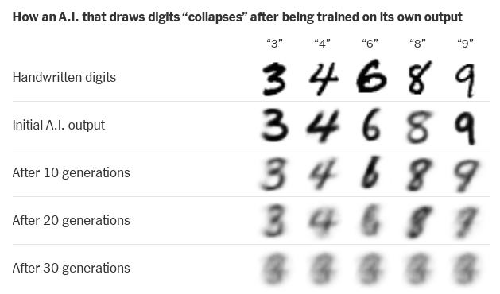

AI Collapse

## Guiding Principles

- Alternative course title: How to Use Statistics to Answer Scientific Questions (part 2)
  - Put science before statistics
  - Emphasize parameter estimates and confidence intervals (credible intervals, likelihood intervals) over hypothesis testing and p-values
    - The End of Statistical Significance (Jonathan Sterne)
    - What’s Wrong with P-Values (Bland, Altman)
    - Key difference between scientific/clinical significance and statistical significance
- This is a course in Biostatistics, not coding in R/Stata
  - I will show you how to get an interpret the key statistics, but not interpret every number on output
  - Often there is more than one way to arrive at identical final answers

- 5 clinical trials conducted to determine if drug A, B, or C lowers cholesterol
- Assume that a decrease of 10 mg/dl or more is important to clinicians
- Study design
  - Cholesterol measured at baseline, subjects take drug for 1 month, Cholesterol measured at 1 month
  - Change in cholesterol is the outcome of interest

| Trial | Drug | Pts | Mean diff | Std dev | Std error | 95% CI for diff | p-value |
| --- | --- | --- | --- | --- | --- | --- | --- |
| 1 | A | 30 | -30 | 191.7 | 49.5 | [-129, 69] | 0.55 |
| 2 | A | 1000 | -30 | 223.6 | 10 | [-49.6, -10.4] | 0.002 |
| 3 | B | 40 | -20 | 147.6 | 33 | [-85, 45] | 0.55 |
| 4 | B | 4000 | -2 | 147.6 | 3.3 | [-8.5, 4.5] | 0.54 |
| 5 | C | 5000 | -6 | 100.0 | 2 | [-9.9, -2.1] | 0.002 |

# Grading and Evaluation

## Evaluation components and grade percentages

- Midterm (25%)
- Take Home Exam (25%)
- Final Exam (25%)
- Homework (25%)
- Class participation
- This is a 4-credit course. Your lab and lecture grades will be the same

## Homework

- Up to 1 per week (probably 6 or 7 total)
- Will focus on real data analysis and interpretation with some mathematical derivations of important quantities
- Questions will focus on specific analyses, with questions stated in as scientific terms as possible
- Work handed in should address the scientific questions
  - Format Table and Figures
- Keys will be provided shortly after the homework is turned in
  - No late homework accepted after the key is posted
- Answers in keys may go beyond what is expected of your homework and present concepts in more detail. You are responsible for any material in the keys for exams.
- You may discuss the homework with others in the class, but the work you turn in should be your own
- Use Brightspace to turn in homeworks and receive feedback and grade

## In Class Exams

- Midterm and Final in class
  - Focus on understanding concepts, not memorizing formulas
  - I will provide an example midterm and final
  - For midterm, you will be allowed 1 page of your own notes
  - For final, you will be allowed 2 pages of your own notes
- All output will be provide for you to interpret

## Take Home Exam

- Will be given approximately mid point between Midterm and Final
- Demonstrate ability to obtain results through software and interpret findings
- One day to complete and turn in
  - Likely will be a Monday with no lab scheduled for that day
- Practice for applied portion of first year comprehensive exams
- Similar to Homework, but work should be your own

# Course Materials

## Course notes

- Course notes will be the primary source
- Available on web page
- Daily class schedule will indicate notes being covered
- Notes will be updated throughout semester

## Recommended Textbook: Regression Methods in Biostatistics

- Vittinghoff, Glidden, Shiboski, and McCulloch
- Pros
  - Covers applied linear, logistic, survival, and repeated measures regression
  - Biomedical orientation
- Cons
  - Does not discuss robust standard errors, which I will use almost exclusively
  - Emphasizes model diagnostics more that I will
  - Does not cover Bayesian approaches
  - Does not cover matrix algebra
  - Little theory and mathematical derivation

## Additional textbooks

- Weisberg, Applied Linear Regression
  - Uses matrix notation and appropriate level of statistical theory for this course
  - Poor for applied data analysis. Earlier version limited to linear models, no Bayesian approaches. Newer version is more comprehensive.
- Wakefield, Bayesian and Frequentist Regression Methods
  - Newer text that I am still evaluating
  - Provides a Bayesian approach to fitting the models we discuss
- I will give recommended readings throughout the semester
- If the course notes and book differ, go with the notes

## Supplemental Material

- As needed, I will post supplemental material on the course web page or on Brightspace
  - I prefer the course web page, if possible
  - Brightspace will be used if necessary
- Relevant supplemental material will be noted on course schedule

## Getting started

- To do on your own by Tuesday
  - Download and install new versions of R and Rstudio
    - Details on course web page, computing
- I would like everyone (including Stata users) to be able to Render a basic Quarto document
- Plan to discuss Quarto intro on Tuesday
  - It is difficult to anticipate all issues that might arise, so I would like to resolve any major software issues before then